# Zelina_Genel_IE582_HW1

### IE582 - Homework I - Zelina Genel

## Introduction

```python
hw1_input <- read.csv("~/Desktop/IE582/HW1/hw1_files/hw1_input.csv")
hw1_real <- read.csv("~/Desktop/IE582/HW1/hw1_files/hw1_real.csv", header=FALSE)
hw1_img <- read.csv("~/Desktop/IE582/HW1/hw1_files/hw1_img.csv", header=FALSE)
```

```python
install.packages("ggplot2")
library(ggplot2)
install.packages("zoo")
library(zoo)
install.packages("quantmod")
library(quantmod)
```

The first rows of real and imaginary datasets are irrelevant. We delete them and reset the indexing:

```python
hw1_real <- hw1_real[-1, ]
hw1_img <- hw1_img[-1, ]
rownames(hw1_real) <- NULL
rownames(hw1_img) <- NULL
```

Before starting the analysis, let's explore the datasets given to understand beforehand what we are dealing with. We have numeric data for all datasets. We have 11 features, 385 observations and 201 different frequencies.

```python
str(hw1_input)
```

```python
'data.frame':	385 obs. of  11 variables:
 $ length.of.patch                           : num  3.2 2.11 3.25 4.16 4.82 ...
 $ width.of.patch                            : num  2.29 2.9 4.82 2.29 2.95 ...
 $ height.of.patch                           : num  0.0125 0.0372 0.0254 0.0111 0.0197 ...
 $ height.of.substrate                       : num  0.139 0.149 0.579 0.117 0.164 ...
 $ height.of.solder.resist.layer             : num  0.0418 0.0568 0.03 0.0932 0.0943 ...
 $ radius.of.the.probe                       : num  0.0286 0.0289 0.0309 0.0176 0.0258 ...
 $ c_pad                                     : num  0.000549 0.005536 0.020274 0.001135 0.021725 ...
 $ c_antipad                                 : num  0.0324 0.0536 0.0498 0.0986 0.0728 ...
 $ c_probe                                   : num  0.3481 0.3264 0.4466 0.0557 0.2723 ...
 $ dielectric.constant.of.substrate          : num  3.74 4.93 4.77 4.1 2.53 ...
 $ dielectric.constant.of.solder.resist.layer: num  4.28 4.88 4.75 3.76 3.05 ...
```

```python
summary(hw1_input)
```

```python
 length.of.patch width.of.patch  height.of.patch   height.of.substrate
 Min.   :1.806   Min.   :1.801   Min.   :0.01001   Min.   :0.1003
 1st Qu.:2.756   1st Qu.:2.501   1st Qu.:0.01619   1st Qu.:0.1269
 Median :3.638   Median :3.215   Median :0.02420   Median :0.1553
 Mean   :3.569   Mean   :3.537   Mean   :0.02427   Mean   :0.3476
 3rd Qu.:4.369   3rd Qu.:4.830   3rd Qu.:0.03169   3rd Qu.:0.6493
 Max.   :5.200   Max.   :5.199   Max.   :0.03984   Max.   :0.7991
 height.of.solder.resist.layer radius.of.the.probe     c_pad
 Min.   :0.02004               Min.   :0.01501     Min.   :3.143e-06
 1st Qu.:0.03869               1st Qu.:0.02339     1st Qu.:6.985e-03
 Median :0.06076               Median :0.03098     Median :1.245e-02
 Mean   :0.06007               Mean   :0.03220     Mean   :1.280e-02
 3rd Qu.:0.08025               3rd Qu.:0.04182     3rd Qu.:1.901e-02
 Max.   :0.09973               Max.   :0.04996     Max.   :2.500e-02
   c_antipad          c_probe        dielectric.constant.of.substrate
 Min.   :0.02529   Min.   :0.05081   Min.   :2.023
 1st Qu.:0.04201   1st Qu.:0.14857   1st Qu.:2.998
 Median :0.06053   Median :0.24505   Median :3.866
 Mean   :0.06065   Mean   :0.24559   Mean   :3.704
 3rd Qu.:0.07823   3rd Qu.:0.34020   3rd Qu.:4.376
 Max.   :0.09995   Max.   :0.44960   Max.   :4.999
 dielectric.constant.of.solder.resist.layer
 Min.   :2.002
 1st Qu.:2.784
 Median :3.481
 Mean   :3.522
 3rd Qu.:4.279
 Max.   :5.000
```

```python
str(hw1_real)
```

```python
'data.frame':	385 obs. of  201 variables:
 $ V1  : num  0.649 -0.684 0.67 -0.856 -0.953 ...
 $ V2  : num  0.609 -0.681 0.678 -0.855 -0.952 ...
 $ V3  : num  0.564 -0.677 0.686 -0.854 -0.951 ...
 $ V4  : num  0.515 -0.674 0.693 -0.853 -0.95 ...
 $ V5  : num  0.464 -0.67 0.7 -0.852 -0.949 ...
 $ V6  : num  0.411 -0.666 0.707 -0.851 -0.948 ...
 $ V7  : num  0.356 -0.662 0.714 -0.85 -0.947 ...
 $ V8  : num  0.3 -0.659 0.72 -0.848 -0.946 ...
 $ V9  : num  0.244 -0.655 0.726 -0.847 -0.945 ...
 $ V10 : num  0.187 -0.651 0.731 -0.846 -0.943 ...
```

The values of real component change between -0.9931360 to 0.9188282.

```python
all_values <- unlist(hw1_real)
lowest_values <- sort(all_values, decreasing = FALSE)[1:5]
highest_values <- sort(all_values, decreasing = TRUE)[1:5]
print(lowest_values)
```

```python
     V3164      V4164      V2164      V5164      V1164
-0.9931360 -0.9931316 -0.9931245 -0.9931120 -0.9930968
```

```python
print(highest_values)
```

```python
    V1573     V1583     V1563     V1593     V1553
0.9188282 0.9187437 0.9186368 0.9183812 0.9181709
```

```python
str(hw1_img)
```

```python
'data.frame':	385 obs. of  201 variables:
 $ V1  : num  -0.435 0.711 0.55 0.507 0.25 ...
 $ V2  : num  -0.493 0.714 0.538 0.509 0.254 ...
 $ V3  : num  -0.547 0.717 0.526 0.511 0.259 ...
 $ V4  : num  -0.597 0.72 0.513 0.513 0.263 ...
 $ V5  : num  -0.642 0.723 0.501 0.514 0.267 ...
 $ V6  : num  -0.682 0.727 0.488 0.516 0.272 ...
 $ V7  : num  -0.717 0.73 0.475 0.518 0.276 ...
 $ V8  : num  -0.748 0.733 0.461 0.52 0.28 ...
 $ V9  : num  -0.774 0.736 0.448 0.521 0.284 ...
 $ V10 : num  -0.795 0.739 0.434 0.523 0.289 ...
```

The values of imaginary component change between -0.8954282 to 0.9422793

```python
all_values2 <- unlist(hw1_img)
lowest_values2 <- sort(all_values2, decreasing = FALSE)[1:5]
highest_values2 <- sort(all_values2, decreasing = TRUE)[1:5]
print(lowest_values2)
```

```python
    V10309      V9309     V11309      V8309     V12309
-0.8954282 -0.8953013 -0.8937531 -0.8931935 -0.8904483
```

```python
print(highest_values2)
```

```python
   V12165    V12265    V12065    V12365    V11965
0.9422793 0.9422392 0.9419441 0.9417767 0.9412755
```

Let's see if there is any missing values that would require imputation.

Data seems complete and we do not need to perform any imputation.

```python
colSums(is.na(hw1_input))
```

```python
   length.of.patch
                                         0
                            width.of.patch
                                         0
                           height.of.patch
                                         0
                       height.of.substrate
                                         0
             height.of.solder.resist.layer
                                         0
                       radius.of.the.probe
                                         0
                                     c_pad
                                         0
                                 c_antipad
                                         0
                                   c_probe
                                         0
          dielectric.constant.of.substrate
                                         0
dielectric.constant.of.solder.resist.layer
                                         0
```

Let's plot the first 6 rows of real and imaginary components to observe the behavior.

```python
data6_plot_real <- hw1_real[1:6, ]
matplot(t(data6_plot_real), type = "l", lty = 1, col = 1:6, xlab = "Frequencies", ylab = "Real Component",
main = "First Six Rows of Data")
```

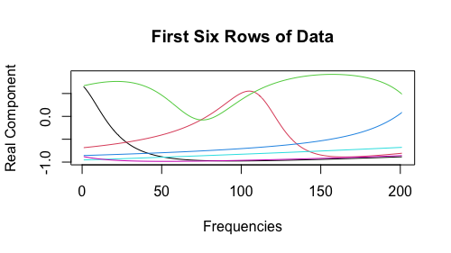

```python
data6_plot_img <- hw1_img[1:6, ]
matplot(t(data6_plot_img), type = "l", lty = 1, col = 1:6, xlab = "Frequencies", ylab = "Img Component",
main = "First Six Rows of Data")
```

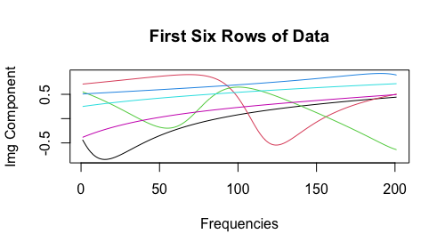

Based on real and imaginary components, the magnitude of S11 value is computed as follows:

```python
magnitude_s11 <- sqrt(hw1_real^2+hw1_img^2)
```

To see if this magnitude expression works, we check the plot of first 6 rows. It is the same as the one given in the homework description.

It is also seen that, S11 magnitude behavior is very different than the behavior of real and imaginary components. It seems more logical to move forward with the S11 magnitude when performing regression related tasks, because, ultimately, we are interested in the total magnitude generated (preferably lowest).

```python
data6_plot <- magnitude_s11[1:6, ]
matplot(t(data6_plot), type = "l", lty = 1, col = 1:6, xlab = "Frequencies", ylab = "S11 Values", main = "First Six Rows of Data")
```

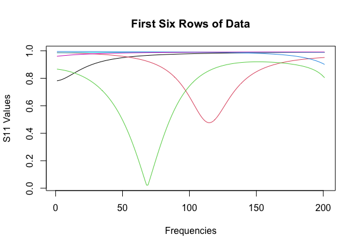

The whole dataset over 201 frequencies;

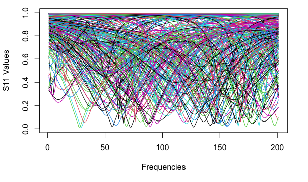

Lastly, let us also see the correlation between variables.

We see few correlated variables. For example, width.of.patch and height.of.substrate are highly correlated; dielectric.constant.of.substrate and height.of.substrate has also correlation; c_probe and c_antipad is somewhat correlated.

```python
cor_matrix <- cor(hw1_input)
print(cor_matrix)
```

```python
                                           length.of.patch width.of.patch height.of.patch height.of.substrate
length.of.patch                                1.000000000    -0.11417384     -0.02603197        -0.064343925
width.of.patch                                -0.114173838     1.00000000      0.09172574         0.923739177
height.of.patch                               -0.026031974     0.09172574      1.00000000         0.082833400
height.of.substrate                           -0.064343925     0.92373918      0.08283340         1.000000000
height.of.solder.resist.layer                  0.044501770    -0.02105555      0.03604491        -0.011870246
radius.of.the.probe                           -0.069904535     0.03567518      0.03068912         0.017410148
c_pad                                         -0.005560154    -0.04419845      0.00242201        -0.031570678
c_antipad                                     -0.009627304    -0.01335778      0.03758257        -0.009432011
c_probe                                        0.081734722     0.02999903      0.03159241         0.044165512
dielectric.constant.of.substrate              -0.037447806     0.44219338     -0.04431754         0.459846618
dielectric.constant.of.solder.resist.layer    -0.014495695     0.03874586     -0.03776888         0.002420837
                                           height.of.solder.resist.layer radius.of.the.probe        c_pad
length.of.patch                                               0.04450177       -0.0699045348 -0.005560154
width.of.patch                                               -0.02105555        0.0356751757 -0.044198447
height.of.patch                                               0.03604491        0.0306891240  0.002422010
height.of.substrate                                          -0.01187025        0.0174101485 -0.031570678
height.of.solder.resist.layer                                 1.00000000       -0.0127562158 -0.018044245
radius.of.the.probe                                          -0.01275622        1.0000000000  0.002906155
c_pad                                                        -0.01804425        0.0029061549  1.000000000
c_antipad                                                    -0.01707067       -0.0005231856  0.067677684
c_probe                                                       0.02484211        0.0480879748 -0.015500215
dielectric.constant.of.substrate                             -0.01096653       -0.0257281569 -0.049318442
dielectric.constant.of.solder.resist.layer                   -0.03840494        0.0075236725  0.015283927
                                               c_antipad     c_probe dielectric.constant.of.substrate
length.of.patch                            -0.0096273042  0.08173472                      -0.03744781
width.of.patch                             -0.0133577777  0.02999903                       0.44219338
height.of.patch                             0.0375825680  0.03159241                      -0.04431754
height.of.substrate                        -0.0094320113  0.04416551                       0.45984662
height.of.solder.resist.layer              -0.0170706717  0.02484211                      -0.01096653
radius.of.the.probe                        -0.0005231856  0.04808797                      -0.02572816
c_pad                                       0.0676776845 -0.01550022                      -0.04931844
c_antipad                                   1.0000000000 -0.13232080                      -0.01674092
c_probe                                    -0.1323207967  1.00000000                       0.01564016
dielectric.constant.of.substrate           -0.0167409193  0.01564016                       1.00000000
dielectric.constant.of.solder.resist.layer  0.0678205174 -0.02910079                       0.06040161
                                           dielectric.constant.of.solder.resist.layer
length.of.patch                                                          -0.014495695
width.of.patch                                                            0.038745861
height.of.patch                                                          -0.037768883
height.of.substrate                                                       0.002420837
height.of.solder.resist.layer                                            -0.038404940
radius.of.the.probe                                                       0.007523673
c_pad                                                                     0.015283927
c_antipad                                                                 0.067820517
c_probe                                                                  -0.029100791
dielectric.constant.of.substrate                                          0.060401607
dielectric.constant.of.solder.resist.layer                                1.000000000
```

## Dimentionality Reduction with Principal Component Analysis (PCA)

In this section, we try to reduce dimention of this high-dimensional data and capture the important information by deducing it. Principal Component Analysis (PCA) does this by transforming the original data into a lower-dimensional one while regulating highly correlated variables together. This makes understanding the data easier.

Before performing PCA, the data needs to be scaled:

```python
scaled_hw1_input <- scale(hw1_input)
```

Let's see few variables of scaled data to observe the behavior.

```python
pairs(scaled_hw1_input, main = "Scatter Plot Matrix of Scaled Features")
plot(scaled_hw1_input[, 1], scaled_hw1_input[, 2],
      main = "Scatter Plot of Scaled Feature 1 vs. Feature 2",
      xlab = "Feature 1 (scaled)",
      ylab = "Feature 2 (scaled)")
```

[output not shown]

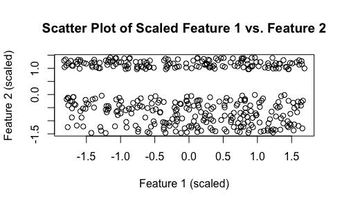

```python
plot(scaled_hw1_input[, 2], scaled_hw1_input[, 3],
            main = "Scatter Plot of Scaled Feature 2 vs. Feature 3",
            xlab = "Feature 2 (scaled)",
            ylab = "Feature 3 (scaled)")
```

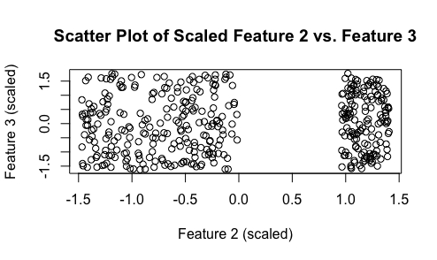

Although through these scatter plots, it does not seem convincing that normality and linearity assumptions are met for PCA, we move forward with it to see its performance.

We can perform PCA with built-in function of R:

```python
pca_hw1_input <- princomp(scaled_hw1_input)
summary(pca_hw1_input)
```

```python
Importance of components:
                          Comp.1    Comp.2    Comp.3     Comp.4     Comp.5     Comp.6
Standard deviation     1.5075708 1.1021015 1.0476231 1.02666993 1.00396904 0.98514643
Proportion of Variance 0.2071535 0.1107083 0.1000338 0.09607237 0.09187079 0.08845826
Cumulative Proportion  0.2071535 0.3178617 0.4178956 0.51396794 0.60583873 0.69429699
                           Comp.7     Comp.8     Comp.9    Comp.10     Comp.11
Standard deviation     0.96943388 0.94647923 0.89737831 0.79978980 0.270965295
Proportion of Variance 0.08565904 0.08165053 0.07339863 0.05830268 0.006692127
Cumulative Proportion  0.77995603 0.86160656 0.93500519 0.99330787 1.000000000
```

As seen above, the first component explains 0.2071 of total variance and first 8 components contribute to 0.862 of cumulative variance. This implies that first 8 components can accurately represent our data.

Let's visualize the components and see them on plots:

```python
install.packages("factoextra")
library(factoextra)
```

```python
fviz_pca_var(pca_hw1_input, col.var = "cos2",
              gradient.cols = c("black", "orange", "green"),
              repel = TRUE)
```

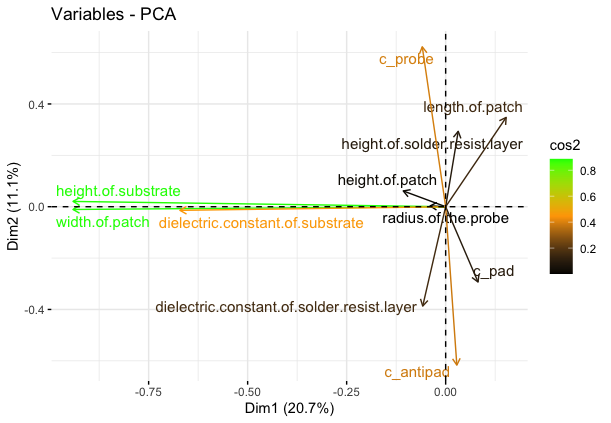

Now, we investigate how these components relate to the features. To understand each design parameter's contribution to components, we need to see loadings of selected first 8 components.

```python
pca_hw1_input$loadings[, 1:8]
```

```python
                                                Comp.1       Comp.2      Comp.3      Comp.4
length.of.patch                             0.10132741  0.315408842  0.36964527  0.37688295
width.of.patch                             -0.62417829 -0.009718499 -0.04076605  0.03963118
height.of.patch                            -0.07105448  0.055716040 -0.62046049  0.39297428
height.of.substrate                        -0.62413737  0.018824259 -0.01644133  0.07651758
height.of.solder.resist.layer               0.02104923  0.266259030 -0.08641719  0.51065245
radius.of.the.probe                        -0.02599671  0.002815433 -0.54838143 -0.45439655
c_pad                                       0.05422779 -0.265990343 -0.14482720  0.17753347
c_antipad                                   0.01872008 -0.559498738 -0.08832260  0.37392613
c_probe                                    -0.03921288  0.564753240 -0.09313062 -0.15100401
dielectric.constant.of.substrate           -0.44510015 -0.012829465  0.25616695 -0.02249200
dielectric.constant.of.solder.resist.layer -0.03842190 -0.350944251  0.25533941 -0.18497498
                                                Comp.5      Comp.6        Comp.7      Comp.8
length.of.patch                             0.40983307  0.07331421  0.2533314291  0.45426579
width.of.patch                              0.01216945 -0.03232618 -0.0004130418  0.02209045
height.of.patch                             0.01770092  0.06971352  0.4900976182 -0.31794295
height.of.substrate                         0.02801155 -0.06056478 -0.0028365899  0.05948121
height.of.solder.resist.layer              -0.12462902  0.45984071 -0.6471989728 -0.11040840
radius.of.the.probe                         0.21898604  0.30490770 -0.2127792894  0.49147848
c_pad                                       0.58005880 -0.54757851 -0.4299761277 -0.17438597
c_antipad                                   0.12775861  0.17214008  0.1381457743  0.41588332
c_probe                                     0.48754352  0.01628526  0.1025282056 -0.12927872
dielectric.constant.of.substrate            0.01225358  0.02777211 -0.0972904093  0.05322583
dielectric.constant.of.solder.resist.layer  0.42031440  0.59170842  0.0868134573 -0.46029597
```

We can see the contributions of components on scree plot:

[figure not shown]

```python
plot(pca_hw1_input, type = "l", main = "Scree Plot")
```

From the loadings matrix we can represent PC1 approximately as;

PC1 = 0.101*length.of.patch-0.624*width.of.patch -0.071*height.of.patch -0.624*height.of.substrate +0.02*height.of.solder.resist.layer -0.025*radius.of.the.probe+0.054*c_pad+0.019*c_antipad -0.039*c_probe -0.445*dielectric.constant.of.substrate -0.038*dielectric.constant.of.solder.resist.layer

This implies that PC1 has high absolute values for width.of.patch, height.of.substrate and dielectric.constant.of.substrate which indicates that these parameters are the most influential ones affecting S11 value. Their signs are negative which is good because it means that they have inverse relationship with S11 magnitude and lower S11 values are better.

We also see that length.of.patch, height.of.solder.resist.layer, c_pad and c_antipad have positive contributions though not significant; and height.of.patch, radius.of.the.probe, c_probe and dielectric.constant.of.solder.resist.layer have negative contribution, again, not significant.

Barplot for PC1;

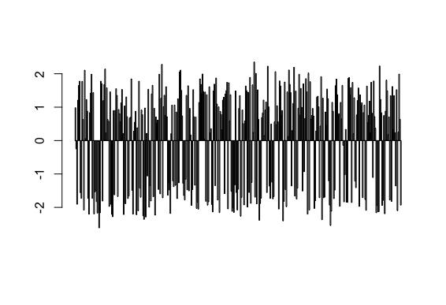

```python
barplot(pca_hw1_input$scores[,1])
```

We can analyze remaining PCs in the similar fashion. More generally, it does not seem as there is consistency among PCs in terms of key variables, i.e. while width.of.patch is significant for PC1, it does not seem as such for PC2. In addition to that, the signs of key variables also varies from PC to PC.

Since PC1 has the greatest of variance coverage, we take PC1 as reference component and accordingly, the key parameters that most influence the S11 response of the antenna are selected as width.of.patch, height.of.substrate and dielectric.constant.of.substrate.

## Regression Modeling

To build a regression model, we need to select some critical frequencies as our output data. Since lower S11 magnitudes are better, let's see which frequencies generate the 10 lowest S11 value.

```python
magnitude_s11_long <- as.data.frame(as.table(as.matrix(magnitude_s11)))
colnames(magnitude_s11_long) <- c("Observation", "Frequency", "Value")
output_sorted <- magnitude_s11_long[order(magnitude_s11_long$Value), ]
lowest_10 <- head(output_sorted, 10)
print(lowest_10)
```

```python
      Observation Frequency       Value
27474          I5       V72 0.005620531
10797           Q       V29 0.008276456
10422          A1       V28 0.010554045
48787         Q10      V127 0.012866228
59805          Z4      V156 0.015969917
32818          O3       V86 0.017632777
34252         H14       V89 0.018066261
21518         E13       V56 0.018487830
10037          A1       V27 0.018742975
66397          U6      V173 0.019610757
```

It is seen that frequency corresponding to V72 column has the lowest S11 value in the dataset and can be a good candidate to investigate.

So can V29 and V28 as they are among the lowest 3 frequencies.

Let's create output columns to be used in regression:

```python
magnitude_s11_v72 <- magnitude_s11[ ,72]
magnitude_s11_v29 <- magnitude_s11[ ,29]
magnitude_s11_v28 <- magnitude_s11[ ,28]
```

We start with V72 output and create corresponding training and test data. We divide 70% of the data as training and 30% as test data.

```python
set.seed(123)
sample_index <- sample(1:nrow(hw1_input), 0.7 * nrow(hw1_input))
train_input <- hw1_input[sample_index, ]
train_output <- magnitude_s11_v72[sample_index]
test_input <- hw1_input[-sample_index, ]
test_output <- magnitude_s11_v72[-sample_index]
train_data <- data.frame(train_input, train_output)
test_data <- data.frame(test_input, test_output)
colnames(train_data)[ncol(train_data)] <- "S11_V72"
```

Now that we have training and test data separately, we can build the regression model by using all features.

I believe, it is also possible to select significant variables from PCs matrix and build the regression accordingly, however, I would like to see how it performs with whole data and I expect it to produce the same significant variables as it did in PCA part.

```python
lm_v72_tt = lm(S11_V72~ length.of.patch + width.of.patch + height.of.patch + height.of.substrate + height.of.solder.resist.layer + radius.of.the.probe + c_pad + c_antipad + c_probe + dielectric.constant.of.substrate + dielectric.constant.of.solder.resist.layer, data = train_data)
summary(lm_v72_tt)
```

```python
Call:
lm(formula = S11_V72 ~ length.of.patch + width.of.patch + height.of.patch +
    height.of.substrate + height.of.solder.resist.layer + radius.of.the.probe +
    c_pad + c_antipad + c_probe + dielectric.constant.of.substrate +
    dielectric.constant.of.solder.resist.layer, data = train_data)

Residuals:
     Min       1Q   Median       3Q      Max
-0.70148 -0.05047  0.03163  0.09216  0.30050

Coefficients:
                                            Estimate Std. Error
(Intercept)                                 1.388049   0.101794
length.of.patch                            -0.002294   0.009973
width.of.patch                             -0.075976   0.021367
height.of.patch                             0.291560   1.105904
height.of.substrate                        -0.324847   0.092353
height.of.solder.resist.layer              -0.444102   0.403106
radius.of.the.probe                        -0.876694   0.928050
c_pad                                      -1.745360   1.360951
c_antipad                                   0.092454   0.438607
c_probe                                     0.074445   0.087355
dielectric.constant.of.substrate           -0.044452   0.012947
dielectric.constant.of.solder.resist.layer  0.002302   0.011384
                                           t value Pr(>|t|)
(Intercept)                                 13.636  < 2e-16 ***
length.of.patch                             -0.230 0.818238
width.of.patch                              -3.556 0.000449 ***
height.of.patch                              0.264 0.792269
height.of.substrate                         -3.517 0.000515 ***
height.of.solder.resist.layer               -1.102 0.271623
radius.of.the.probe                         -0.945 0.345718
c_pad                                       -1.282 0.200838
c_antipad                                    0.211 0.833218
c_probe                                      0.852 0.394890
dielectric.constant.of.substrate            -3.433 0.000695 ***
dielectric.constant.of.solder.resist.layer   0.202 0.839914
---
Signif. codes:  0 ‘***’ 0.001 ‘**’ 0.01 ‘*’ 0.05 ‘.’ 0.1 ‘ ’ 1

Residual standard error: 0.1552 on 257 degrees of freedom
Multiple R-squared:  0.6156,	Adjusted R-squared:  0.5991
F-statistic: 37.41 on 11 and 257 DF,  p-value: < 2.2e-16
```

In alignment with PCA result, width.of.patch, height.of.substrate and dielectric.constant.of.substrate seems significant for this first regression model as well.

The resulting multiple R-squared is 0.6156.

Let's remove some insignificant variables, i.e. length.of.patch, height.of.patch, c_antipad and dielectric.constant.of.solder.resist.layer, to see if model improves.

```python
lm_v72_tt2 = lm(S11_V72~ width.of.patch + height.of.substrate + height.of.solder.resist.layer + radius.of.the.probe + c_pad + c_probe + dielectric.constant.of.substrate, data = train_data)
summary(lm_v72_tt2)
```

```python
Call:
lm(formula = S11_V72 ~ width.of.patch + height.of.substrate +
    height.of.solder.resist.layer + radius.of.the.probe + c_pad +
    c_probe + dielectric.constant.of.substrate, data = train_data)

Residuals:
     Min       1Q   Median       3Q      Max
-0.69784 -0.05076  0.03280  0.08760  0.30344

Coefficients:
                                 Estimate Std. Error t value Pr(>|t|)
(Intercept)                       1.39808    0.07944  17.600  < 2e-16
width.of.patch                   -0.07495    0.02093  -3.580 0.000409
height.of.substrate              -0.32852    0.09094  -3.613 0.000364
height.of.solder.resist.layer    -0.44669    0.39729  -1.124 0.261907
radius.of.the.probe              -0.86156    0.92038  -0.936 0.350094
c_pad                            -1.69779    1.34617  -1.261 0.208364
c_probe                           0.06972    0.08558   0.815 0.416019
dielectric.constant.of.substrate -0.04427    0.01276  -3.468 0.000612

(Intercept)                      ***
width.of.patch                   ***
height.of.substrate              ***
height.of.solder.resist.layer
radius.of.the.probe
c_pad
c_probe
dielectric.constant.of.substrate ***
---
Signif. codes:  0 ‘***’ 0.001 ‘**’ 0.01 ‘*’ 0.05 ‘.’ 0.1 ‘ ’ 1

Residual standard error: 0.1541 on 261 degrees of freedom
Multiple R-squared:  0.6152,	Adjusted R-squared:  0.6049
F-statistic: 59.62 on 7 and 261 DF,  p-value: < 2.2e-16
```

Removing aforementioned variables and all insignificant variables does not seem to effect the model since the resulting multiple R-squared remains almost the same. Therefore "lm_v72_tt2" is our regression model for frequency level V72.

Let's try the second selected frequency corresponding to column V29 with a different seed.

```python
set.seed(124)
sample_index2 <- sample(1:nrow(hw1_input), 0.7 * nrow(hw1_input))
train_input2 <- hw1_input[sample_index2, ]
train_output2 <- magnitude_s11_v29[sample_index2]
test_input2 <- hw1_input[-sample_index2, ]
test_output2 <- magnitude_s11_v29[-sample_index2]
train_data2 <- data.frame(train_input2, train_output2)
test_data2 <- data.frame(test_input2, test_output2)
colnames(train_data2)[ncol(train_data2)] <- "S11_V29"
```

Based on the training data we build the regression model for frequency level V29 as follows:

```python
lm_v29_tt = lm(S11_V29~ length.of.patch + width.of.patch + height.of.patch + height.of.substrate + height.of.solder.resist.layer + radius.of.the.probe + c_pad + c_antipad + c_probe + dielectric.constant.of.substrate + dielectric.constant.of.solder.resist.layer, data = train_data2)
summary(lm_v29_tt)
```

```python
Call:
lm(formula = S11_V29 ~ length.of.patch + width.of.patch + height.of.patch +
    height.of.substrate + height.of.solder.resist.layer + radius.of.the.probe +
    c_pad + c_antipad + c_probe + dielectric.constant.of.substrate +
    dielectric.constant.of.solder.resist.layer, data = train_data2)

Residuals:
     Min       1Q   Median       3Q      Max
-0.68095 -0.02243  0.01115  0.05584  0.17579

Coefficients:
                                            Estimate Std. Error t value Pr(>|t|)
(Intercept)                                 1.280180   0.076549  16.724  < 2e-16
length.of.patch                            -0.003957   0.007249  -0.546  0.58557
width.of.patch                             -0.016335   0.015461  -1.057  0.29170
height.of.patch                            -0.601042   0.768317  -0.782  0.43477
height.of.substrate                        -0.358130   0.066836  -5.358 1.87e-07
height.of.solder.resist.layer              -0.075399   0.291081  -0.259  0.79582
radius.of.the.probe                        -0.877362   0.657820  -1.334  0.18347
c_pad                                      -0.674742   0.996793  -0.677  0.49907
c_antipad                                   0.048099   0.321023   0.150  0.88102
c_probe                                    -0.086625   0.062239  -1.392  0.16518
dielectric.constant.of.substrate           -0.028105   0.009097  -3.090  0.00223
dielectric.constant.of.solder.resist.layer -0.008701   0.007898  -1.102  0.27165

(Intercept)                                ***
length.of.patch
width.of.patch
height.of.patch
height.of.substrate                        ***
height.of.solder.resist.layer
radius.of.the.probe
c_pad
c_antipad
c_probe
dielectric.constant.of.substrate           **
dielectric.constant.of.solder.resist.layer
---
Signif. codes:  0 ‘***’ 0.001 ‘**’ 0.01 ‘*’ 0.05 ‘.’ 0.1 ‘ ’ 1

Residual standard error: 0.1126 on 257 degrees of freedom
Multiple R-squared:  0.5781,	Adjusted R-squared:   0.56
F-statistic: 32.01 on 11 and 257 DF,  p-value: < 2.2e-16
```

With this version, we lose width.of.patch which is a significant variable for previous regression model and also due to PCA. Furthermore, the R-squared value decreases. Hence, we eliminate this model.

As our last individual column, let us see how frequency level V28 performs.

```python
set.seed(125)
sample_index3 <- sample(1:nrow(hw1_input), 0.7 * nrow(hw1_input))
train_input3 <- hw1_input[sample_index3, ]
train_output3 <- magnitude_s11_v28[sample_index3]
test_input3 <- hw1_input[-sample_index3, ]
test_output3 <- magnitude_s11_v28[-sample_index3]
train_data3 <- data.frame(train_input3, train_output3)
test_data3 <- data.frame(test_input3, test_output3)
colnames(train_data3)[ncol(train_data3)] <- "S11_V28"
```

Based on the training data we build the regression model for frequency level V28 as follows:

```python
lm_v28_tt = lm(S11_V28~ length.of.patch + width.of.patch + height.of.patch + height.of.substrate + height.of.solder.resist.layer + radius.of.the.probe + c_pad + c_antipad + c_probe + dielectric.constant.of.substrate + dielectric.constant.of.solder.resist.layer, data = train_data3)
summary(lm_v28_tt)
```

```python
Call:
lm(formula = S11_V28 ~ length.of.patch + width.of.patch + height.of.patch +
    height.of.substrate + height.of.solder.resist.layer + radius.of.the.probe +
    c_pad + c_antipad + c_probe + dielectric.constant.of.substrate +
    dielectric.constant.of.solder.resist.layer, data = train_data3)

Residuals:
     Min       1Q   Median       3Q      Max
-0.66929 -0.02148  0.01517  0.05894  0.19087

Coefficients:
                                            Estimate Std. Error t value Pr(>|t|)
(Intercept)                                 1.245305   0.080345  15.499  < 2e-16
length.of.patch                            -0.008755   0.007934  -1.103  0.27086
width.of.patch                             -0.010679   0.016973  -0.629  0.52980
height.of.patch                            -0.346406   0.875157  -0.396  0.69257
height.of.substrate                        -0.400088   0.074647  -5.360 1.85e-07
height.of.solder.resist.layer               0.064876   0.320298   0.203  0.83965
radius.of.the.probe                        -0.891862   0.746592  -1.195  0.23335
c_pad                                      -1.090576   1.055689  -1.033  0.30255
c_antipad                                   0.123069   0.355598   0.346  0.72956
c_probe                                    -0.050300   0.068457  -0.735  0.46315
dielectric.constant.of.substrate           -0.028737   0.010037  -2.863  0.00454
dielectric.constant.of.solder.resist.layer -0.003052   0.008895  -0.343  0.73176

(Intercept)                                ***
length.of.patch
width.of.patch
height.of.patch
height.of.substrate                        ***
height.of.solder.resist.layer
radius.of.the.probe
c_pad
c_antipad
c_probe
dielectric.constant.of.substrate           **
dielectric.constant.of.solder.resist.layer
---
Signif. codes:  0 ‘***’ 0.001 ‘**’ 0.01 ‘*’ 0.05 ‘.’ 0.1 ‘ ’ 1

Residual standard error: 0.1225 on 257 degrees of freedom
Multiple R-squared:  0.554,	Adjusted R-squared:  0.535
F-statistic: 29.03 on 11 and 257 DF,  p-value: < 2.2e-16
```

Model for frequency level V28 generates a similar model to V29, hence eliminated.

Before settling for the first regression model which performs the best so far, let's try if the combined effect of V72 and V29 (frequency columns that produce the lowest two S11 values) would change anything. To this end, we take the averages of these columns as our output:

```python
combined_v72_v29_data <- data.frame(magnitude_s11_v72, magnitude_s11_v29)
magnitude_s11_v72_v29_avg <- rowMeans(combined_v72_v29_data, na.rm = TRUE)
set.seed(126)
sample_index4 <- sample(1:nrow(hw1_input), 0.7 * nrow(hw1_input))
train_input4 <- hw1_input[sample_index4, ]
train_output4 <- magnitude_s11_v72_v29_avg[sample_index4]
test_input4 <- hw1_input[-sample_index4, ]
test_output4 <- magnitude_s11_v72_v29_avg[-sample_index4]
train_data4 <- data.frame(train_input4, train_output4)
test_data4 <- data.frame(test_input4, test_output4)
colnames(train_data4)[ncol(train_data4)] <- "S11_V72_V29"
```

The respective regression model is;

```python
lm_v72_v29_tt = lm(S11_V72_V29~ length.of.patch + width.of.patch + height.of.patch + height.of.substrate + height.of.solder.resist.layer + radius.of.the.probe + c_pad + c_antipad + c_probe + dielectric.constant.of.substrate + dielectric.constant.of.solder.resist.layer, data = train_data4)
summary(lm_v72_v29_tt)
```

```python
Call:
lm(formula = S11_V72_V29 ~ length.of.patch + width.of.patch +
    height.of.patch + height.of.substrate + height.of.solder.resist.layer +
    radius.of.the.probe + c_pad + c_antipad + c_probe + dielectric.constant.of.substrate +
    dielectric.constant.of.solder.resist.layer, data = train_data4)

Residuals:
     Min       1Q   Median       3Q      Max
-0.36180 -0.05167  0.01012  0.06005  0.23271

Coefficients:
                                             Estimate Std. Error t value Pr(>|t|)
(Intercept)                                 1.2416973  0.0672274  18.470  < 2e-16
length.of.patch                             0.0003166  0.0063338   0.050 0.960178
width.of.patch                             -0.0488826  0.0136814  -3.573 0.000421
height.of.patch                            -0.0709818  0.6878077  -0.103 0.917885
height.of.substrate                        -0.3439390  0.0598541  -5.746 2.57e-08
height.of.solder.resist.layer              -0.1835109  0.2554603  -0.718 0.473192
radius.of.the.probe                        -0.6874495  0.5928713  -1.160 0.247318
c_pad                                      -0.0797538  0.8531616  -0.093 0.925595
c_antipad                                   0.5928844  0.2885937   2.054 0.040949
c_probe                                    -0.0222853  0.0550235  -0.405 0.685803
dielectric.constant.of.substrate           -0.0334767  0.0081624  -4.101 5.52e-05
dielectric.constant.of.solder.resist.layer  0.0036502  0.0067376   0.542 0.588450

(Intercept)                                ***
length.of.patch
width.of.patch                             ***
height.of.patch
height.of.substrate                        ***
height.of.solder.resist.layer
radius.of.the.probe
c_pad
c_antipad                                  *
c_probe
dielectric.constant.of.substrate           ***
dielectric.constant.of.solder.resist.layer
---
Signif. codes:  0 ‘***’ 0.001 ‘**’ 0.01 ‘*’ 0.05 ‘.’ 0.1 ‘ ’ 1

Residual standard error: 0.09789 on 257 degrees of freedom
Multiple R-squared:  0.7501,	Adjusted R-squared:  0.7394
F-statistic: 70.14 on 11 and 257 DF,  p-value: < 2.2e-16
```

Using the averages of two frequencies V72 and V29 as output not only restores the significant parameter width.of.patch but also improves the model by increasing R-squared to 0.7501 (compared to 0.6152).

Continuing in this fashion, the averages of three frequencies V72, V29 and V28 is not better than previous one in terms of R-squared value and the significance level of the variables. Its results can be seen below.

```python
combined_v72_v29_v28_data <- data.frame(magnitude_s11_v72, magnitude_s11_v29, magnitude_s11_v28)
magnitude_s11_v72_v29_v28_avg <- rowMeans(combined_v72_v29_v28_data, na.rm = TRUE)
set.seed(127)
sample_index5 <- sample(1:nrow(hw1_input), 0.7 * nrow(hw1_input))
train_input5 <- hw1_input[sample_index5, ]
train_output5 <- magnitude_s11_v72_v29_v28_avg[sample_index5]
test_input5 <- hw1_input[-sample_index5, ]
test_output5 <- magnitude_s11_v72_v29_v28_avg[-sample_index5]
train_data5 <- data.frame(train_input5, train_output5)
test_data5 <- data.frame(test_input5, test_output5)
colnames(train_data5)[ncol(train_data5)] <- "S11_V72_V29_V28"
```

The respective regression model is;

```python
lm_v72_v29_v28_tt = lm(S11_V72_V29_V28~ length.of.patch + width.of.patch + height.of.patch + height.of.substrate + height.of.solder.resist.layer + radius.of.the.probe + c_pad + c_antipad + c_probe + dielectric.constant.of.substrate + dielectric.constant.of.solder.resist.layer, data = train_data5)
summary(lm_v72_v29_v28_tt)
```

```python
Call:
lm(formula = S11_V72_V29_V28 ~ length.of.patch + width.of.patch +
    height.of.patch + height.of.substrate + height.of.solder.resist.layer +
    radius.of.the.probe + c_pad + c_antipad + c_probe + dielectric.constant.of.substrate +
    dielectric.constant.of.solder.resist.layer, data = train_data5)

Residuals:
     Min       1Q   Median       3Q      Max
-0.36304 -0.04144  0.01135  0.05775  0.19933

Coefficients:
                                             Estimate Std. Error t value Pr(>|t|)
(Intercept)                                 1.238e+00  6.079e-02  20.357  < 2e-16
length.of.patch                             1.123e-03  6.106e-03   0.184  0.85428
width.of.patch                             -3.921e-02  1.295e-02  -3.028  0.00271
height.of.patch                             5.733e-01  6.518e-01   0.880  0.37988
height.of.substrate                        -3.160e-01  5.631e-02  -5.612 5.16e-08
height.of.solder.resist.layer              -3.389e-01  2.295e-01  -1.477  0.14099
radius.of.the.probe                        -4.946e-01  5.568e-01  -0.888  0.37522
c_pad                                       1.525e-02  7.801e-01   0.020  0.98442
c_antipad                                   4.102e-01  2.683e-01   1.529  0.12757
c_probe                                    -1.262e-01  5.098e-02  -2.476  0.01394
dielectric.constant.of.substrate           -3.071e-02  7.375e-03  -4.164 4.27e-05
dielectric.constant.of.solder.resist.layer -4.142e-05  6.561e-03  -0.006  0.99497

(Intercept)                                ***
length.of.patch
width.of.patch                             **
height.of.patch
height.of.substrate                        ***
height.of.solder.resist.layer
radius.of.the.probe
c_pad
c_antipad
c_probe                                    *
dielectric.constant.of.substrate           ***
dielectric.constant.of.solder.resist.layer
---
Signif. codes:  0 ‘***’ 0.001 ‘**’ 0.01 ‘*’ 0.05 ‘.’ 0.1 ‘ ’ 1

Residual standard error: 0.09174 on 257 degrees of freedom
Multiple R-squared:  0.7178,	Adjusted R-squared:  0.7058
F-statistic: 59.44 on 11 and 257 DF,  p-value: < 2.2e-16
```

Therefore, we will use lm_v72_v29_tt as our final regression model. We also remove the insignificant variables from this model. Then the final regression model is;

```python
lm_v72_v29_tt = lm(S11_V72_V29~ width.of.patch + height.of.substrate + height.of.solder.resist.layer + radius.of.the.probe + c_antipad + c_probe +
dielectric.constant.of.substrate + dielectric.constant.of.solder.resist.layer, data = train_data4)
```

```python
lm_v72_v29_tt = lm(S11_V72_V29~ width.of.patch + height.of.substrate + height.of.solder.resist.layer + radius.of.the.probe + c_antipad + c_probe + dielectric.constant.of.substrate + dielectric.constant.of.solder.resist.layer, data = train_data4)
summary(lm_v72_v29_tt)
```

```python
Call:
lm(formula = S11_V72_V29 ~ width.of.patch + height.of.substrate +
    height.of.solder.resist.layer + radius.of.the.probe + c_antipad +
    c_probe + dielectric.constant.of.substrate + dielectric.constant.of.solder.resist.layer,
    data = train_data4)

Residuals:
     Min       1Q   Median       3Q      Max
-0.36268 -0.05200  0.01034  0.05999  0.23230

Coefficients:
                                            Estimate Std. Error t value Pr(>|t|)
(Intercept)                                 1.240109   0.056546  21.931  < 2e-16
width.of.patch                             -0.048995   0.013430  -3.648 0.000319
height.of.substrate                        -0.343736   0.059086  -5.818 1.75e-08
height.of.solder.resist.layer              -0.181740   0.253580  -0.717 0.474204
radius.of.the.probe                        -0.688157   0.588187  -1.170 0.243087
c_antipad                                   0.589665   0.286065   2.061 0.040269
c_probe                                    -0.022465   0.054586  -0.412 0.681014
dielectric.constant.of.substrate           -0.033395   0.008093  -4.126 4.97e-05
dielectric.constant.of.solder.resist.layer  0.003685   0.006685   0.551 0.581930

(Intercept)                                ***
width.of.patch                             ***
height.of.substrate                        ***
height.of.solder.resist.layer
radius.of.the.probe
c_antipad                                  *
c_probe
dielectric.constant.of.substrate           ***
dielectric.constant.of.solder.resist.layer
---
Signif. codes:  0 ‘***’ 0.001 ‘**’ 0.01 ‘*’ 0.05 ‘.’ 0.1 ‘ ’ 1

Residual standard error: 0.09733 on 260 degrees of freedom
Multiple R-squared:  0.7501,	Adjusted R-squared:  0.7424
F-statistic: 97.55 on 8 and 260 DF,  p-value: < 2.2e-16
```

Next, we check the linearity and normality assumptions of linear regression to see if there is any significant violations.

Checking linearity:

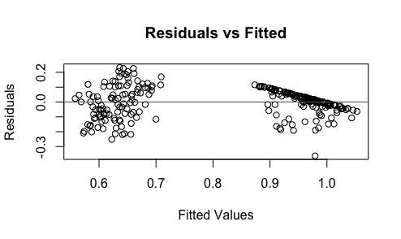

```python
plot(fitted(lm_v72_v29_tt), residuals(lm_v72_v29_tt),
      main = "Residuals vs Fitted",
      xlab = "Fitted Values", ylab = "Residuals")
 abline(h = 0, col = "red")
```

Checking normality:

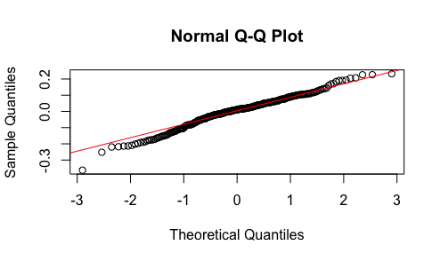

```python
Normality assumption seems to hold however linearity is not ideal. Nevertheless, we move forward with predictions on test data.
```

Now, let's see how it predicts the test data for S11 magnitudes (including both with real and imaginary parts):

```python
predictions <- predict(lm_v72_v29_tt, newdata = test_input4)
mse <- mean((test_output4 - predictions)^2)
print(mse)
```

```python
[1] 0.01060361
```

We also need to see how it predicts real and imaginary parts of the S11 magnitude. To do so, we create test outputs from real and img datasets for frequency levels V72 and V29 separately with same indexing of regression model's training dataset's indexing.

```python
v72_real <- hw1_real[ ,72]
v72_img <- hw1_img[ ,72]
v29_real <- hw1_real[ ,29]
v29_img <- hw1_img[ ,29]
set.seed(126)
test_output4_v72_real <- v72_real[-sample_index4]
test_output4_v29_real <- v29_real[-sample_index4]
test_output4_v72_img <- v72_img[-sample_index4]
test_output4_v29_img <- v29_img[-sample_index4]
```

```python
predictions_v72_real <- predict(lm_v72_v29_tt, newdata = test_input4)
mse_v72_real <- mean((test_output4_v72_real - predictions_v72_real)^2)
print(mse_v72_real)
```

```python
[1] 1.976837
```

```python
predictions_v72_img <- predict(lm_v72_v29_tt, newdata = test_input4)
mse_v72_img <- mean((test_output4_v72_img - predictions_v72_img)^2)
print(mse_v72_img)
```

```python
[1] 0.4750655
```

```python
predictions_v29_real <- predict(lm_v72_v29_tt, newdata = test_input4)
mse_v29_real <- mean((test_output4_v29_real - predictions_v29_real)^2)
print(mse_v29_real)
```

```python
[1] 2.027307
```

```python
predictions_v29_img <- predict(lm_v72_v29_tt, newdata = test_input4)
mse_v29_img <- mean((test_output4_v29_img - predictions_v29_img)^2)
print(mse_v29_img)
```

```python
[1] 0.4122347
```

Although the model does a good job predicting the S11 magnitude, unfortunately, it does not perform well for real and imaginary components of frequency levels V72 and V29. This is not surprising to me since we have seen the very different behavior of S11 magnitude compared to respective real and imaginary components on the plots.

It suggests that to predict real and imaginary components, other suitable regression models need to be employed.

Let's try to fit a model for component parts separately with same frequency level V72.

```python
real_v72 <- hw1_real[ ,72]
img_v72 <- hw1_img[ ,72]
```

```python
set.seed(134)
sample_index7 <- sample(1:nrow(hw1_input), 0.7 * nrow(hw1_input))
train_input7 <- hw1_input[sample_index7, ]
train_output7 <- real_v72[sample_index7]
test_input7 <- hw1_input[-sample_index7, ]
test_output7 <- real_v72[-sample_index7]
train_data7 <- data.frame(train_input7, train_output7)
test_data7 <- data.frame(test_input7, test_output7)
```

The regression model;

```python
lm_v72_real = lm(train_output7~ length.of.patch + width.of.patch + height.of.patch + height.of.substrate + height.of.solder.resist.layer + radius.of.the.probe + c_pad + c_antipad + c_probe + dielectric.constant.of.substrate + dielectric.constant.of.solder.resist.layer, data = train_data7)
summary(lm_v72_real)
```

```python
Call:
lm(formula = train_output7 ~ length.of.patch + width.of.patch +
    height.of.patch + height.of.substrate + height.of.solder.resist.layer +
    radius.of.the.probe + c_pad + c_antipad + c_probe + dielectric.constant.of.substrate +
    dielectric.constant.of.solder.resist.layer, data = train_data7)

Residuals:
     Min       1Q   Median       3Q      Max
-0.71583 -0.18107 -0.05356  0.12863  1.44778

Coefficients:
                                           Estimate Std. Error t value Pr(>|t|)
(Intercept)                                -0.94521    0.19512  -4.844  2.2e-06 ***
length.of.patch                            -0.02758    0.01934  -1.426   0.1551
width.of.patch                              0.06926    0.04015   1.725   0.0857 .
height.of.patch                             0.02475    2.12335   0.012   0.9907
height.of.substrate                         2.02110    0.17855  11.320  < 2e-16 ***
height.of.solder.resist.layer               0.35879    0.77325   0.464   0.6430
radius.of.the.probe                        -3.51114    1.75466  -2.001   0.0464 *
c_pad                                       0.54809    2.63976   0.208   0.8357
c_antipad                                  -0.65721    0.84181  -0.781   0.4357
c_probe                                     0.37064    0.16771   2.210   0.0280 *
dielectric.constant.of.substrate           -0.05999    0.02463  -2.436   0.0155 *
dielectric.constant.of.solder.resist.layer  0.02140    0.02111   1.014   0.3115
---
Signif. codes:  0 ‘***’ 0.001 ‘**’ 0.01 ‘*’ 0.05 ‘.’ 0.1 ‘ ’ 1

Residual standard error: 0.2964 on 257 degrees of freedom
Multiple R-squared:  0.815,	Adjusted R-squared:  0.807
F-statistic: 102.9 on 11 and 257 DF,  p-value: < 2.2e-16
```

```python
predictions_v72_real_2 <- predict(lm_v72_real, newdata = test_input7)
mse_v72_real_2 <- mean((test_output7 - predictions_v72_real_2)^2)
print(mse_v72_real_2)
```

```python
[1] 0.1152604
```

This regression model built with respect to only real component works better for real component of frequency level V72. MSE value also significantly drops accordingly. However, using this frequency for imaginary component does not work well. This expected because their behavior is different and most likely we need to build a regression models customized to these components, that is, we need to select key frequencies for real and imaginary parts separately and build the models with those outputs as we did for S11 magnitude regression model.

We do not analyze the components any further and stop at this point with these closing remarks since the total magnitude prediction is our prominent goal and we already developed the model for it.

The regression model for imaginary component with frequency level V72; R-squared is very low.

```python
set.seed(135)
sample_index8 <- sample(1:nrow(hw1_input), 0.7 * nrow(hw1_input))
train_input8 <- hw1_input[sample_index8, ]
train_output8 <- img_v72[sample_index8]
test_input8 <- hw1_input[-sample_index8, ]
test_output8 <- img_v72[-sample_index8]
train_data8 <- data.frame(train_input8, train_output8)
test_data8 <- data.frame(test_input8, test_output8)
```

```python
lm_v72_img = lm(train_output8~ length.of.patch + width.of.patch + height.of.patch + height.of.substrate + height.of.solder.resist.layer + radius.of.the.probe + c_pad + c_antipad + c_probe + dielectric.constant.of.substrate + dielectric.constant.of.solder.resist.layer, data = train_data8)
summary(lm_v72_img)
```

```python
Call:
lm(formula = train_output8 ~ length.of.patch + width.of.patch +
    height.of.patch + height.of.substrate + height.of.solder.resist.layer +
    radius.of.the.probe + c_pad + c_antipad + c_probe + dielectric.constant.of.substrate +
    dielectric.constant.of.solder.resist.layer, data = train_data8)

Residuals:
     Min       1Q   Median       3Q      Max
-1.03066 -0.13444  0.03164  0.17279  0.76229

Coefficients:
                                           Estimate Std. Error t value Pr(>|t|)
(Intercept)                                 0.17547    0.18973   0.925 0.355910
length.of.patch                             0.05670    0.01935   2.930 0.003691 **
width.of.patch                              0.05634    0.04096   1.375 0.170250
height.of.patch                             0.66487    2.07229   0.321 0.748594
height.of.substrate                        -0.69481    0.17656  -3.935 0.000107 ***
height.of.solder.resist.layer              -0.15329    0.77182  -0.199 0.842730
radius.of.the.probe                        -4.27816    1.77185  -2.415 0.016455 *
c_pad                                      -1.12564    2.66476  -0.422 0.673073
c_antipad                                   2.45863    0.86024   2.858 0.004611 **
c_probe                                    -0.66799    0.16703  -3.999 8.31e-05 ***
dielectric.constant.of.substrate            0.01408    0.02445   0.576 0.565139
dielectric.constant.of.solder.resist.layer  0.00677    0.02192   0.309 0.757670
---
Signif. codes:  0 ‘***’ 0.001 ‘**’ 0.01 ‘*’ 0.05 ‘.’ 0.1 ‘ ’ 1

Residual standard error: 0.297 on 257 degrees of freedom
Multiple R-squared:  0.2725,	Adjusted R-squared:  0.2414
F-statistic: 8.753 on 11 and 257 DF,  p-value: 3.599e-13
```

## Model Performance and Interpretability

PCA approach does not seem to be very effective since we can only reduce to 8 components from total of 11. Furthermore, the PCs have low consistency among themselves. I would expect a consistency for key variables that are influential among PCs, however, we do not see this in terms of coefficients and also the signs of the variables also change, making it difficult to support the argument regarding the influence of a particular variable.

This might be due to the weak linear relationships between variables. PCA works best with linear correlations between variables since it tries to find linear combinations that maximize variance. When this assumption is unvalid, PCA might not be very accurate which I believe is the case for this data. Furthermore, it is not convincing that the data is Gaussian, hence it might be another factor contributing to weak performance.

Regression analysis works relatively well for predicting the S11 magnitude with acceptable R-squared value. However, the model and key frequency level for S11 do not seem to work for real and imaginary components as they result in large MSE. Although not explored in detail, separate regression models for real and imaginary components are needed. We cannot directly predict their values from the regression model of S11 magnitude data. In addition to this, the linearity assumption for linear regression model is not fully met which makes the model not ideal.

In conclusion, with these data it might be a good alternative to build the non-linear models and explore further.

## References

For this homework, I used ChatGPT for most of the coding and some brief insights on PCA application. I made use of Datacamp articles, namely as "Principal Component Analysis in R Tutorial" and "Multiple Linear Regression in R: Tutorial With Examples". I also scanned through past year's submitted repositories to outline the homework structure etc.

## Important Note

Please note that I had trouble connecting R as Kernel to Jupyter Notebook. I tried multiple methods and sought assistance but none worked out. Hence, I am unable to submit the notebook as required. I run all codes in R and manually pasted the outputs and images to lines below. I hope to fix the problem by 2nd homework or I will use Python next time. My apologies for the inconvenience.